# Aleipata MPA

Author

Fimareti Selu

Published

# 1 Preparations

Load the necessary libraries

```r
library(tidyverse)
library(easystats)
library(knitr)
library(sf)
library(rnaturalearth)
library(brms)
library(rstan)
library(tidybayes)
library(patchwork)
library(DHARMa)
library(HDInterval)
library(emmeans)
source('helperFunctions.R')
```

# 2 Read in the data

```r
dat <- read_csv("../data/Aleipata_MPA1.csv", trim_ws = TRUE)
```

**glimpse**

```r
dat |> glimpse()
```

```
Rows: 2,990
Columns: 36
$ `Project name`                <chr> "Aleipata MPA", "Aleipata MPA", "Aleipat…
$ Country                       <chr> "Samoa", "Samoa", "Samoa", "Samoa", "Sam…
$ Site                          <chr> "Amaile", "Amaile", "Amaile", "Amaile", …
$ Latitude                      <dbl> -13.99548, -13.99548, -13.99548, -13.995…
$ Longitude                     <dbl> -171.4279, -171.4279, -171.4279, -171.42…
$ Exposure                      <chr> "sheltered", "sheltered", "sheltered", "…
$ `Reef slope`                  <chr> "flat", "flat", "flat", "flat", "flat", …
$ `Reef type`                   <chr> "lagoon", "lagoon", "lagoon", "lagoon", …
$ `Reef zone`                   <chr> "back reef", "back reef", "back reef", "…
$ Year                          <dbl> 2015, 2015, 2015, 2015, 2015, 2015, 2015…
$ Month                         <dbl> 6, 6, 6, 6, 6, 6, 6, 6, 6, 6, 6, 6, 6, 6…
$ Day                           <dbl> 11, 11, 11, 11, 11, 11, 11, 11, 11, 11, …
$ `Start time`                  <time> 12:37:00, 12:37:00, 12:37:00, 12:37:00,…
```

[output cut: 23 more lines]

**head**

```r
## Explore the first 6 rows of the data
dat |> head()
```

```
# A tibble: 6 × 36
  `Project name` Country Site   Latitude Longitude Exposure  `Reef slope`
  <chr>          <chr>   <chr>     <dbl>     <dbl> <chr>     <chr>
1 Aleipata MPA   Samoa   Amaile    -14.0     -171. sheltered flat
2 Aleipata MPA   Samoa   Amaile    -14.0     -171. sheltered flat
3 Aleipata MPA   Samoa   Amaile    -14.0     -171. sheltered flat
4 Aleipata MPA   Samoa   Amaile    -14.0     -171. sheltered flat
5 Aleipata MPA   Samoa   Amaile    -14.0     -171. sheltered flat
6 Aleipata MPA   Samoa   Amaile    -14.0     -171. sheltered flat
# ℹ 29 more variables: `Reef type` <chr>, `Reef zone` <chr>, Year <dbl>,
#   Month <dbl>, Day <dbl>, `Start time` <time>, Tide <chr>, Visibility <chr>,
#   Current <chr>, Depth <dbl>, `Relative depth` <chr>,
#   `Management name` <chr>, `Management secondary name` <lgl>,
#   `Management year established` <dbl>, `Management size` <dbl>,
#   Governance <chr>, `Estimated compliance` <chr>, `Management rules` <chr>,
#   `Transect number` <dbl>, `Transect label` <chr>, …
```

**str**

```r
dat |> str()
```

```
spc_tbl_ [2,990 × 36] (S3: spec_tbl_df/tbl_df/tbl/data.frame)
 $ Project name               : chr [1:2990] "Aleipata MPA" "Aleipata MPA" "Aleipata MPA" "Aleipata MPA" ...
 $ Country                    : chr [1:2990] "Samoa" "Samoa" "Samoa" "Samoa" ...
 $ Site                       : chr [1:2990] "Amaile" "Amaile" "Amaile" "Amaile" ...
 $ Latitude                   : num [1:2990] -14 -14 -14 -14 -14 ...
 $ Longitude                  : num [1:2990] -171 -171 -171 -171 -171 ...
 $ Exposure                   : chr [1:2990] "sheltered" "sheltered" "sheltered" "sheltered" ...
 $ Reef slope                 : chr [1:2990] "flat" "flat" "flat" "flat" ...
 $ Reef type                  : chr [1:2990] "lagoon" "lagoon" "lagoon" "lagoon" ...
 $ Reef zone                  : chr [1:2990] "back reef" "back reef" "back reef" "back reef" ...
 $ Year                       : num [1:2990] 2015 2015 2015 2015 2015 ...
 $ Month                      : num [1:2990] 6 6 6 6 6 6 6 6 6 6 ...
 $ Day                        : num [1:2990] 11 11 11 11 11 11 11 11 11 11 ...
 $ Start time                 : 'hms' num [1:2990] 12:37:00 12:37:00 12:37:00 12:37:00 ...
  ..- attr(*, "units")= chr "secs"
 $ Tide                       : chr [1:2990] "rising" "rising" "rising" "rising" ...
 $ Visibility                 : chr [1:2990] ">10m - excellent" ">10m - excellent" ">10m - excellent" ">10m - excellent" ...
 $ Current                    : chr [1:2990] "moderate" "moderate" "moderate" "moderate" ...
 $ Depth                      : num [1:2990] 1.5 1.5 1.5 1.5 1.5 1.5 1.5 1.5 1.5 1.5 ...
 $ Relative depth             : chr [1:2990] NA NA NA NA ...
 $ Management name            : chr [1:2990] "Aleipata" "Aleipata" "Aleipata" "Aleipata" ...
 $ Management secondary name  : logi [1:2990] NA NA NA NA NA NA ...
 $ Management year established: num [1:2990] 1999 1999 1999 1999 1999 ...
 $ Management size            : num [1:2990] 4842 4842 4842 4842 4842 ...
 $ Governance                 : chr [1:2990] "community, local government" "community, local government" "community, local government" "community, local government" ...
 $ Estimated compliance       : chr [1:2990] "low" "low" "low" "low" ...
 $ Management rules           : chr [1:2990] "gear restriction,size limits,access restriction" "gear restriction,size limits,access restriction" "gear restriction,size limits,access restriction" "gear restriction,size limits,access restriction" ...
 $ Transect number            : num [1:2990] 1 1 1 1 1 1 1 1 1 1 ...
 $ Transect label             : chr [1:2990] "Right" "Right" "Right" "Right" ...
 $ Transect length surveyed   : num [1:2990] 50 50 50 50 50 50 50 50 50 50 ...
 $ Observers                  : chr [1:2990] "Yashika Nand, Fatutolo Iene" "Yashika Nand, Fatutolo Iene" "Yashika Nand, Fatutolo Iene" "Yashika Nand, Fatutolo Iene" ...
 $ PIT interval (m)           : num [1:2990] 2 4 6 8 10 12 14 16 18 20 ...
 $ Benthic category           : chr [1:2990] "Hard coral" "Hard coral" "Hard coral" "Hard coral" ...
 $ Benthic attribute          : chr [1:2990] "Poritidae" "Poritidae" "Poritidae" "Poritidae" ...
 $ Growth form                : chr [1:2990] "Branching" "Massive" "Massive" "Branching" ...
 $ Site notes                 : logi [1:2990] NA NA NA NA NA NA ...
 $ Management notes           : logi [1:2990] NA NA NA NA NA NA ...
 $ Sample unit notes          : logi [1:2990] NA NA NA NA NA NA ...
 - attr(*, "spec")=
  .. cols(
```

[output cut: 23 more lines]

```
  ..   `Estimated compliance` = col_character(),
  ..   `Management rules` = col_character(),
  ..   `Transect number` = col_double(),
  ..   `Transect label` = col_character(),
  ..   `Transect length surveyed` = col_double(),
  ..   Observers = col_character(),
  ..   `PIT interval (m)` = col_double(),
  ..   `Benthic category` = col_character(),
  ..   `Benthic attribute` = col_character(),
  ..   `Growth form` = col_character(),
  ..   `Site notes` = col_logical(),
  ..   `Management notes` = col_logical(),
  ..   `Sample unit notes` = col_logical()
  .. )
 - attr(*, "problems")=<externalptr>
```

**Easystats (datawizard)**

```r
dat |> datawizard::data_codebook() |> knitr::kable()
```

| ID | Name | Type | Missings | Values | N | Prop | .row_id |
| --- | --- | --- | --- | --- | --- | --- | --- |
| 1 | Project name | character | 0 (0.0%) | Aleipata MPA | 2990 | 100.0% | 1 |
|  |  |  |  |  |  |  | 1 |
| 2 | Country | character | 0 (0.0%) | Samoa | 2990 | 100.0% | 2 |
|  |  |  |  |  |  |  | 2 |
| 3 | Site | character | 0 (0.0%) | Amaile | 26 | 0.9% | 3 |
|  |  |  |  | Malaela | 390 | 13.0% | 3 |
|  |  |  |  | Mutiatele | 390 | 13.0% | 3 |
|  |  |  |  | Saleaumua | 390 | 13.0% | 3 |
|  |  |  |  | Samusu | 390 | 13.0% | 3 |
|  |  |  |  | Satitoa | 780 | 26.1% | 3 |
|  |  |  |  | Ulutogia | 234 | 7.8% | 3 |
|  |  |  |  | Utufaalalafa | 390 | 13.0% | 3 |
|  |  |  |  |  |  |  | 3 |
| 4 | Latitude | numeric | 0 (0.0%) | [-14.35, -14] | 2990 |  | 4 |
|  |  |  |  |  |  |  | 4 |
| 5 | Longitude | numeric | 0 (0.0%) | [-171.67, -171.42] | 2990 |  | 5 |
|  |  |  |  |  |  |  | 5 |
| 6 | Exposure | character | 0 (0.0%) | exposed | 390 | 13.0% | 6 |
|  |  |  |  | semi-exposed | 780 | 26.1% | 6 |
|  |  |  |  | sheltered | 1820 | 60.9% | 6 |
|  |  |  |  |  |  |  | 6 |
| 7 | Reef slope | character | 234 (7.8%) | flat | 2730 | 99.1% | 7 |
|  |  |  |  | slope | 26 | 0.9% | 7 |
|  |  |  |  |  |  |  | 7 |
| 8 | Reef type | character | 0 (0.0%) | fringing | 390 | 13.0% | 8 |
|  |  |  |  | lagoon | 2600 | 87.0% | 8 |
|  |  |  |  |  |  |  | 8 |
| 9 | Reef zone | character | 0 (0.0%) | back reef | 2600 | 87.0% | 9 |
|  |  |  |  | fore reef | 390 | 13.0% | 9 |
|  |  |  |  |  |  |  | 9 |

[output cut: 106 more lines]

# 3 Data preparation

Before we can model these data, they need to be processed into a format compatible with statistical modelling. The necessary wrangling steps:

**Exclude fields**

Although it is often harmless enough to retain the other fields, it does make reviewing the data more combersum, so at an early stage within this exercise, we will probably restrict the data to just the above fields.

```r
dat <- dat |>
  dplyr::select(Site,
    Longitude,
    Latitude,
    Exposure,
    `Reef slope`,
    `Reef type`,
    `Transect number`,
    `Benthic category`,
    )
dat |> as.data.frame() |> head()
```

```
    Site Longitude  Latitude  Exposure Reef slope Reef type Transect number
1 Amaile -171.4279 -13.99548 sheltered       flat    lagoon               1
2 Amaile -171.4279 -13.99548 sheltered       flat    lagoon               1
3 Amaile -171.4279 -13.99548 sheltered       flat    lagoon               1
4 Amaile -171.4279 -13.99548 sheltered       flat    lagoon               1
5 Amaile -171.4279 -13.99548 sheltered       flat    lagoon               1
6 Amaile -171.4279 -13.99548 sheltered       flat    lagoon               1
  Benthic category
1       Hard coral
2       Hard coral
3       Hard coral
4       Hard coral
5       Hard coral
6       Hard coral
```

**Tally up the benthic categories per transect**

```r
dat<-
  dat |>
  group_by(Site,
           Longitude,
           Latitude,
           Exposure,
           `Reef slope`,
           `Reef type`,
           `Transect number`,
           `Benthic category`) |>
  count(name = "COUNT") |>
  ungroup()
```

##fill in the blanks (0s)

```r
data.filler<- dat |>
  dplyr::select(Site, Latitude, Longitude, Exposure, `Reef slope`,
           `Reef type`,`Transect number`) |>
  distinct() |>
  crossing(`Benthic category` = unique(dat$`Benthic category`))
data.filler
```

```
# A tibble: 315 × 8
   Site   Latitude Longitude Exposure `Reef slope` `Reef type` `Transect number`
   <chr>     <dbl>     <dbl> <chr>    <chr>        <chr>                   <dbl>
 1 Amaile    -14.0     -171. shelter… flat         lagoon                      1
 2 Amaile    -14.0     -171. shelter… flat         lagoon                      1
 3 Amaile    -14.0     -171. shelter… flat         lagoon                      1
 4 Amaile    -14.0     -171. shelter… flat         lagoon                      1
 5 Amaile    -14.0     -171. shelter… flat         lagoon                      1
 6 Amaile    -14.0     -171. shelter… flat         lagoon                      1
 7 Amaile    -14.0     -171. shelter… flat         lagoon                      1
 8 Amaile    -14.0     -171. shelter… flat         lagoon                      1
 9 Amaile    -14.0     -171. shelter… flat         lagoon                      1
10 Malae…    -14.0     -171. semi-ex… flat         lagoon                      1
# ℹ 305 more rows
# ℹ 1 more variable: `Benthic category` <chr>
```

```r
dat <-
  dat |>
 #filter(Site == "Amaile", `Transect number` == 1) |>
  full_join(data.filler) |> # |>  filter(Site == "Amaile", `Transect number` == 1)) |>
  mutate(COUNT = ifelse(is.na(COUNT), 0, COUNT)) |>
  group_by(Site, `Transect number`) |>
  mutate(TOTAL = sum(COUNT)) |>
  ungroup()
```

[output not shown]

```r
#dat |>
#  filter(Site == "Amaile", `Transect number` == 1) |>
#  full_join(data.filler |>  filter(Site == "Amaile", `Transect number` == 1)) |>
#
#    as.data.frame()
```

**Recode transects**

```r
dat <-
  dat |>
  mutate(transect_id = paste0(Site, `Transect number`))
dat |> as.data.frame() |> head()
```

```
     Site Longitude  Latitude     Exposure Reef slope Reef type Transect number
1  Amaile -171.4279 -13.99548    sheltered       flat    lagoon               1
2  Amaile -171.4279 -13.99548    sheltered       flat    lagoon               1
3  Amaile -171.4279 -13.99548    sheltered       flat    lagoon               1
4  Amaile -171.4279 -13.99548    sheltered       flat    lagoon               1
5  Amaile -171.4279 -13.99548    sheltered       flat    lagoon               1
6 Malaela -171.4261 -14.02153 semi-exposed       flat    lagoon               1
  Benthic category COUNT TOTAL transect_id
1   Bare substrate     2    26     Amaile1
2       Hard coral    15    26     Amaile1
3       Macroalgae     2    26     Amaile1
4           Rubble     4    26     Amaile1
5             Sand     3    26     Amaile1
6   Bare substrate    12    78    Malaela1
```

**Declare all character vectors as categorical**

```r
dat <-
  dat |>
  mutate(across(where(is.character), factor),
         Reef_type = factor(`Reef type`))

dat |> as.data.frame() |> head()
```

```
     Site Longitude  Latitude     Exposure Reef slope Reef type Transect number
1  Amaile -171.4279 -13.99548    sheltered       flat    lagoon               1
2  Amaile -171.4279 -13.99548    sheltered       flat    lagoon               1
3  Amaile -171.4279 -13.99548    sheltered       flat    lagoon               1
4  Amaile -171.4279 -13.99548    sheltered       flat    lagoon               1
5  Amaile -171.4279 -13.99548    sheltered       flat    lagoon               1
6 Malaela -171.4261 -14.02153 semi-exposed       flat    lagoon               1
  Benthic category COUNT TOTAL transect_id Reef_type
1   Bare substrate     2    26     Amaile1    lagoon
2       Hard coral    15    26     Amaile1    lagoon
3       Macroalgae     2    26     Amaile1    lagoon
4           Rubble     4    26     Amaile1    lagoon
5             Sand     3    26     Amaile1    lagoon
6   Bare substrate    12    78    Malaela1    lagoon
```

## 3.1 Exploratory data analysis

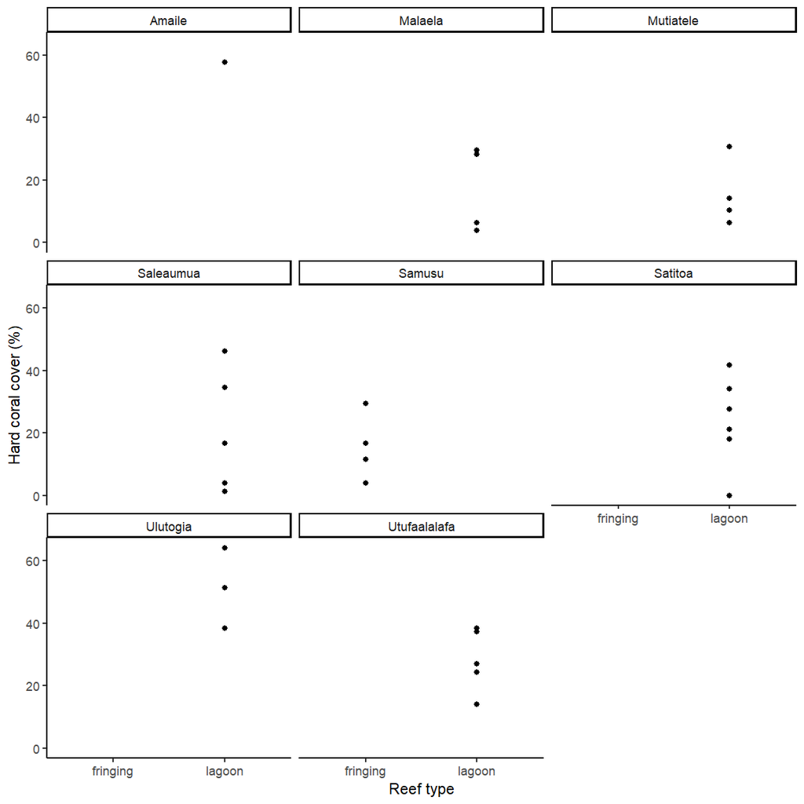

```r
dat |>
  filter(`Benthic category` == "Hard coral") |>
  ggplot(aes(y =  100*COUNT/TOTAL, x = `Reef type`)) +
  geom_point() +
  #geom_line(aes(group = transect_id)) +
  scale_y_continuous("Hard coral cover (%)") +
  #scale_colour_discrete("Survey depth (m)") +
  #scale_x_datetime("Year", date_breaks = "1 years", date_labels = "%Y") +
  facet_wrap(~Site) +
  theme_classic()
```

**Conclusions -** variances are clearly not equal between the groups

Benthic monitoring programs typically adopt a hierarchical sampling design in which (usually) fixed sampling units (such as quadrats or transects) are nested within in Sites which are in turn nested within progressively larger spatial units (e.g. Reefs within Regions). In such designs, monitors collect data from those same units over multiple years. That is, the units are repeatedly measured.

Such a design is an attempt to control some of the numerous sources of uncertainty that would otherwise make it very difficult to draw out a signal (temporal pattern) amongst the noise. If instead, researchers sampled different locations each year, it is much harder to uncouple how much of any changes are due to genuine temporal shifts and how much is due to just a shift in location.

Whist this design does provide substantial statistical power advantages, it does introduce additional complexities to do with the independence of observations. Repeated observations from the same sampling units (transects etc) are not independent. Similarly, observations of sampling units that are close in space (or time) are likely to be highly correlated. This violates a important assumption that underlies most statistical analyses.

Complex hierarchical statistical designs exist to accommodate these dependency issues. Although such analyses are very powerful, they are not a good starting point when learning how to fit models. This series of workshops is intended to progressively increase the complexity of the statistical designs and analyses.

The current dataset represents only a tiny fraction of a much larger dataset that includes multiple sites, reefs and years. As such, it has been prepared to fill in for a very simple design/analyses.

**Important**

I fully acknowledge this issue and therefore acknowledge that the analysis I will present is completely invalid.

```r
dat_hc <- dat |>
  filter(`Benthic category` == "Hard coral") |>
  droplevels()
```

# 4 Fit models

::: {.panel-tabset}

## 4.1 Binomial model

$$\begin{align}
y_{i} &\sim{} Bin(\pi_{i}, n_{i})\\
log\left(\frac{\pi_i}{1-\pi_i}\right) &= \beta_0 + \beta_{i}\mathbf{X}\\
\beta_0 \sim{} N(0, 1)\\
\beta_{1-3} \sim{} N(0, 1)\\
\end{align}$$

:::: {.panel-tabset}

### 4.1.1 Define priors

```r
model2<-dat_hc |>
  mutate(COVER = COUNT/TOTAL) |>
  group_by(Reef_type) |>
  summarise(
    qlogis(mean(COVER)),
    qlogis(sd(COVER))
  )
```

```r
priors <- prior(normal(0,1), class = "Intercept")+
  prior(normal(0,1), class = "b")

form <- bf(COUNT | trials(TOTAL)~ Reef_type,
           family = binomial(link = "logit"))
#it can be called random intercept model, a 1 stands for intercept. The intercept is conditional on according to reef : the intercept varies according to each column reef-id,site name,transect id
```

```r
priors<- prior(normal(0,1), class = "Intercept") +
  prior(normal (0,3), class = "b")
form<- bf(COUNT | trials(TOTAL) ~ Reef_type, family = binomial (link = "logit"))
model2<- brm(form,
             data = dat,
             prior = priors,
             sample_prior = "only",
             iter = 5000,
             warmup = 1000,
             chains = 3,
             cores = 3,
             thin = 5,
             refresh = 0,
             backend = "rstan")
```

```
Setting all 'trials' variables to 1 by default if not specified otherwise.
```

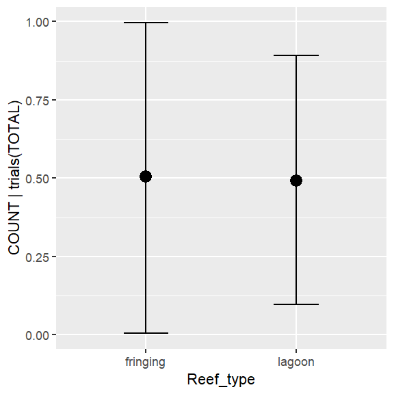

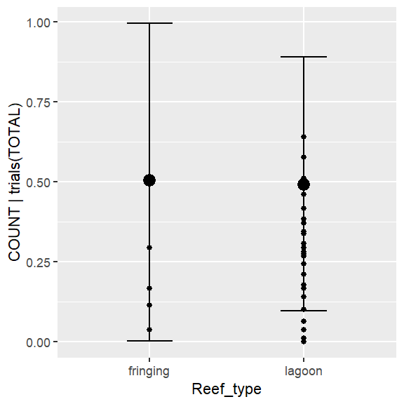

```r
model2|>
  conditional_effects() |>
  plot() |>
  _[[1]]+
  geom_point(data = dat_hc,aes(y = COUNT/TOTAL, x = Reef_type), inherit.aes = FALSE)
```

```r
model2 <- update(model2, sample_prior = "yes", refresh = 1000)
```

```
The desired updates require recompiling the model
```

### 4.1.2 Fit full model

```
Setting all 'trials' variables to 1 by default if not specified otherwise.
```

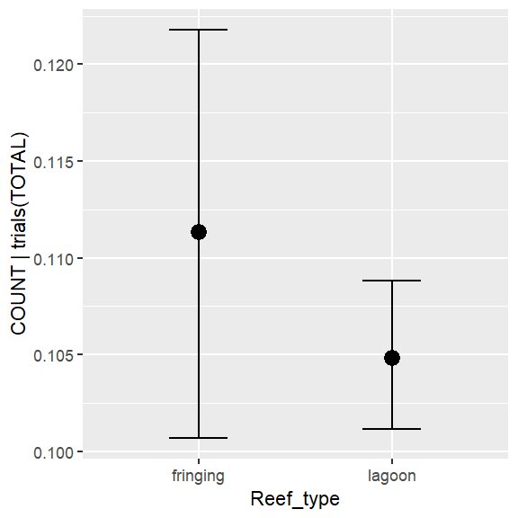

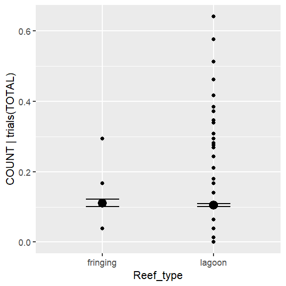

```r
model2 |>
  conditional_effects() |>
  plot() |>
  _[[1]]+
  geom_point(data = dat_hc, aes(y=COUNT/TOTAL, x = Reef_type), inherit.aes = FALSE)
```

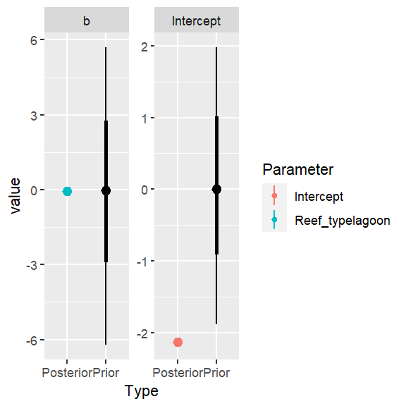

```r
model2 |> SUYR_prior_and_posterior()
```

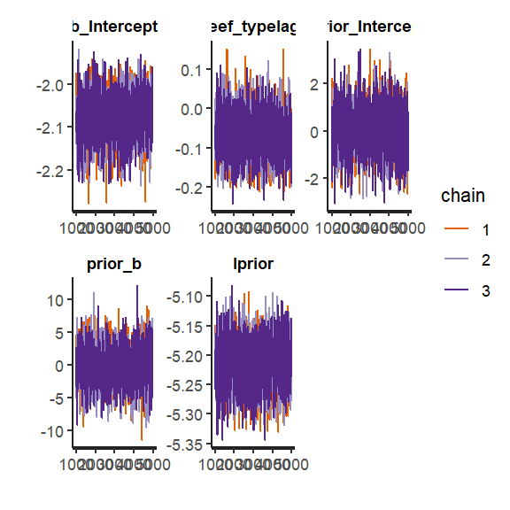

```r
model2$fit |> stan_trace()
```

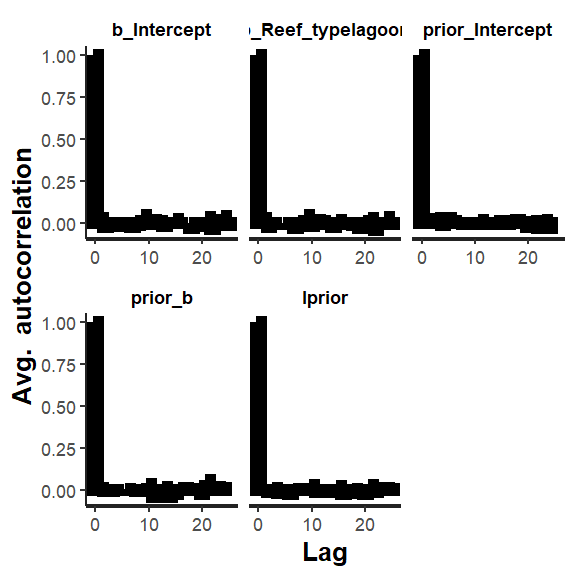

```r
model2$fit |> stan_ac()
```

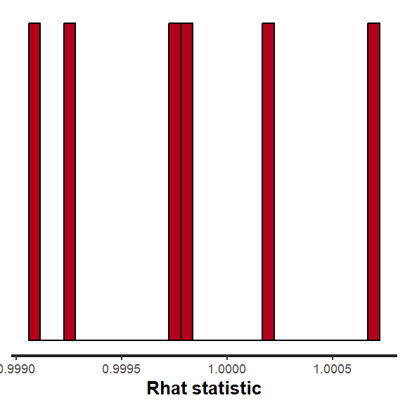

```r
model2$fit |> stan_rhat()
```

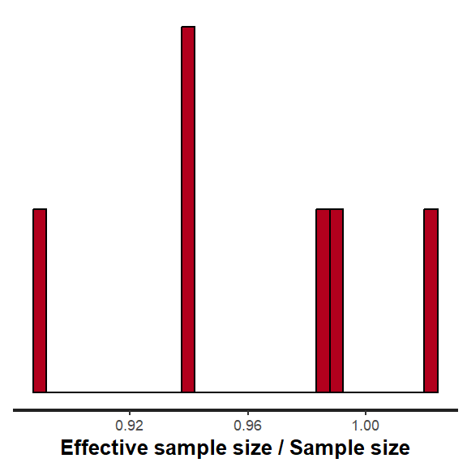

```r
model2$fit |> stan_ess()
```

### 4.1.4 Posterior probability checks

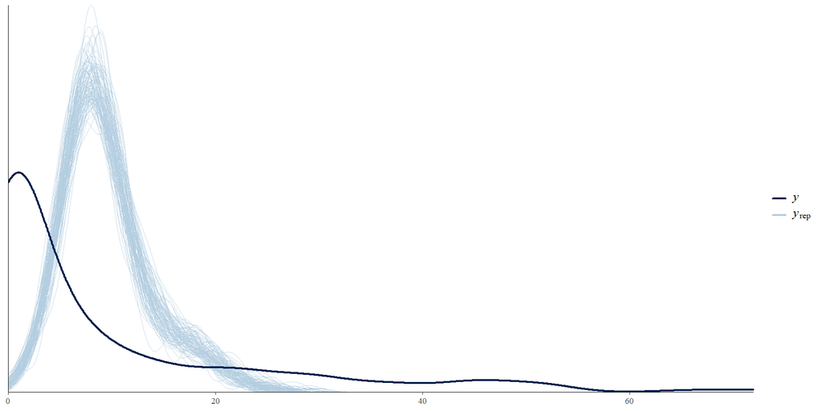

```r
model2 |> pp_check(type = "dens_overlay", ndraws = 100)
```

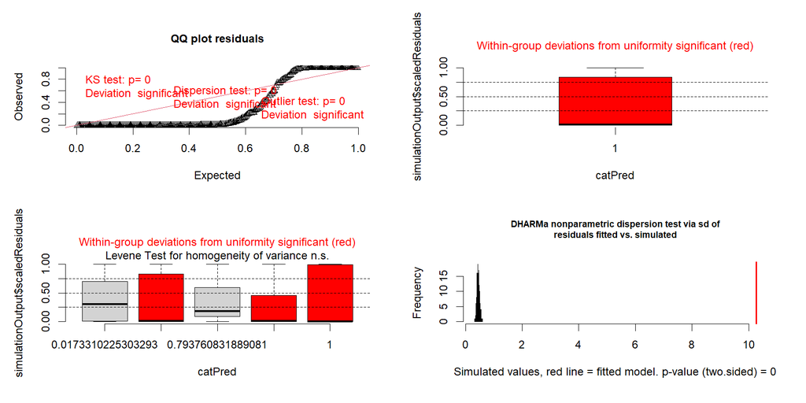

```r
resids <- model2 |> make_brms_dharma_res(integerResponse = FALSE)
wrap_elements(~testUniformity(resids))+
  wrap_elements(~plotResiduals(resids,form = factor(rep(1, nrow(dat)))))+
  wrap_elements(~plotResiduals(resids))+
  wrap_elements(~testDispersion(resids))
```